# CASO PRÁTICO 10 | ECOLOGIA

André Silvestre Nº104532 | Diogo Catarino Nº104745 | Eduardo Silva Nº104943 | Francisco Gomes Nº104944

31 de março de 2022

[figure not shown]

##### **UC:** Análise Exploratória de Dados

##### **Docentes:** Madalena Ramos e Luís Junqueira

.

# **RELATÓRIO**

## **Introdução**

A ecologia é uma vertente crucial do conhecimento no mundo atual tendo em conta um dos principais desafios do Homem de hoje: as alterações globais e a consequente perda de biodiversidade nos ecossistemas.

Desta forma, é indubitável a necessidade de compreender aprofundadamente os principais processos ecológicos, das questões ligadas à perda e gestão da Biodiversidade, bem como da sua importância, incluindo as interações entre as diferentes componentes, bióticas e abióticas, dos próprios Ecossistemas.

Tendo em vista esta temática tão preponderante e, por vezes, tão desprezada, uma equipa de investigadores realizou um estudo, que incluiu a aplicação de um inquérito por questionário. Um dos módulos deste questionário tem como objetivo avaliar a importância atribuída a artigos do ambiente, perceção sobre a gravidade da realidade ambiental, bem como aferir o nível de preocupação com a destruição de recursos naturais. Os dados disponibilizados referem-se às respostas dos residentes em Portugal, relativamente às questões mencionadas e alguma informação de caracterização destes cidadãos.

Assim, pretende-se com este caso prático proposto no âmbito da Unidade Curricular de Análise Exploratória de Dados, desenvolver a preparação e organização do conjunto de dados e correspondente análise descritiva, em função do contexto e objetivos definidos, tendo como auxílio as ferramentas: Excel, Jamovi e R.

Primeiramente, faremos uma descrição do perfil social dos inquiridos; seguidamente, veremos o grau de importância para os problemas ambientais; posteriormente, analisaremos o nível de preocupação destes com a destruição de recursos naturais; e por fim, atentaremos em que medida a educação influencia a sua perspetiva em relação ao ambiente.

.

## **1. Caracterização Social dos Inquiridos**

.

Através da análise dos dados, verifica-se que a amostra em estudo é composta por 696 inquiridos.

.

**Gráfico da Relação da Idade com o Género dos inquiridos**

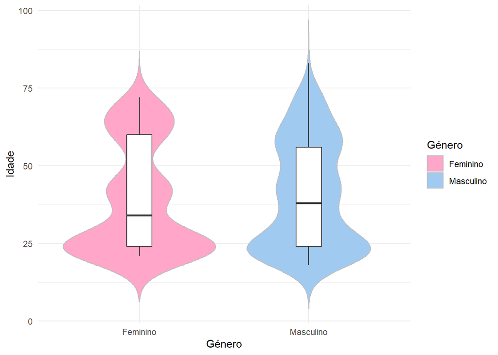

**Gráfico 1 -** Relação da Idade com o Género dos inquiridos.

.

Pela análise do **Gráfico 1**, ainda que se verifique dispersão entre as idades, conclui-se que 50% dos inquiridos do género feminino têm uma idade inferior a, aproximadamente, 34 anos e 50% dos inquiridos do género masculino têm uma idade inferior a 38 anos. Constata-se ainda que, em ambos os géneros, a faixa etária com maior concentração de indivíduos é de 18 a 26 anos.

.

| Medidas Descritivas | Valor |
| --- | --- |
| n | 696.0 |
| Média | 39.8 |
| Mediana | 37.0 |
| Desvio Padrão | 17.2 |
| Variância | 294.6 |
| Mínimo | 18.0 |
| Máximo | 83.0 |
| 1º Quartil | 24.0 |
| 3º Quartil | 56.0 |

.

Analisando descritivamente a idade dos inquiridos verifica-se que esta varia entre os 18 e os 83 anos, sendo a média 39.8 anos (DP = 17.2). (**Tabela 1**)

É de salientar ainda que através da análise simultânea da **Tabela 1** e **Gráfico 1** constata-se que a maior parte dos inquiridos são de faixas etárias jovens, o que corrobora o 1º quartil. Revela, ainda, que de toda a amostra em estudo, 25% tem no máximo 24 anos, sendo que a idade máxima dos inquiridos é 83 anos.

.

**Tabela de Frequências das Habilitações Literárias**

| Habilitações Literarias | n | % |
| --- | --- | --- |
| Primário | 264 | 37.9 |
| Secundário | 257 | 36.9 |
| Superior | 175 | 25.1 |

**Tabela 2 -** Frequências das Habilitações Literárias.

.

A **Tabela 2** é representativa da distribuição das Habilitações Literárias dos inquiridos. Podemos verificar que 37,9% possuem apenas o ensino primário, sendo o grupo dominante. Com menos 1 ponto percentual, representa-se o grupo que possui o ensino secundário, ao passo que o ensino superior, representa apenas 25,1% da amostra.

.

**Tabela de Frequências do Estado Civil**

| Estado Civil | n | % | % acumulada |
| --- | --- | --- | --- |
| Solteiro | 254 | 37.5 | 37.5 |
| Casado | 374 | 55.2 | 92.7 |
| Separado | 34 | 5.0 | 97.7 |
| Viúvo | 15 | 2.2 | 99.9 |

**Tabela 3 -** Frequências do Estado Civil.

.

Relativamente ao Estado Civil (**Tabela 3**), dos 696 inquiridos, obtiveram-se 19 não respostas, o que se traduz numa taxa aproximada de 2,7% de abstenção. O estado civil que melhor caracteriza a amostra é o de “casado”, com 55,2% do total de respostas.

O estado de solteiro, com uma percentagem acumulada de 92,7% (aliada aos casados) é o segundo maior estado civil presente nas respostas. Com menor significância, seguem-se o estado de separado (5%) e o de viúvo (2.2%). (**Tabela 3**)

.

## **2. Grau de Importância de Problemas Ambientais**

.

O principal objetivo de investigação que pretendemos desenvolver neste trabalho é perceber de que forma o perfil de um indivíduo se pode relacionar com as suas perceções em relação à ecologia e ao meio ambiente. Neste sentido apresentamos de seguida diversos gráficos e tabelas que pretendem dar resposta a esta questão.

De modo a compreender a opinião da amostra em estudo relativamente ao grau de importância que têm os problemas ambientais, foi solicitado aos inquiridos que classificassem de 1 (“Nada Importante”) a 5 (“Muito Importante”) três problemas ambientais que predominam na atualidade.

- Poluição nas Praias
- Má Qualidade do Ar que Respiramos
- Utilização de Pesticidas na Agricultura

.

**Gráfico de Barras de Problemas Ambientais**

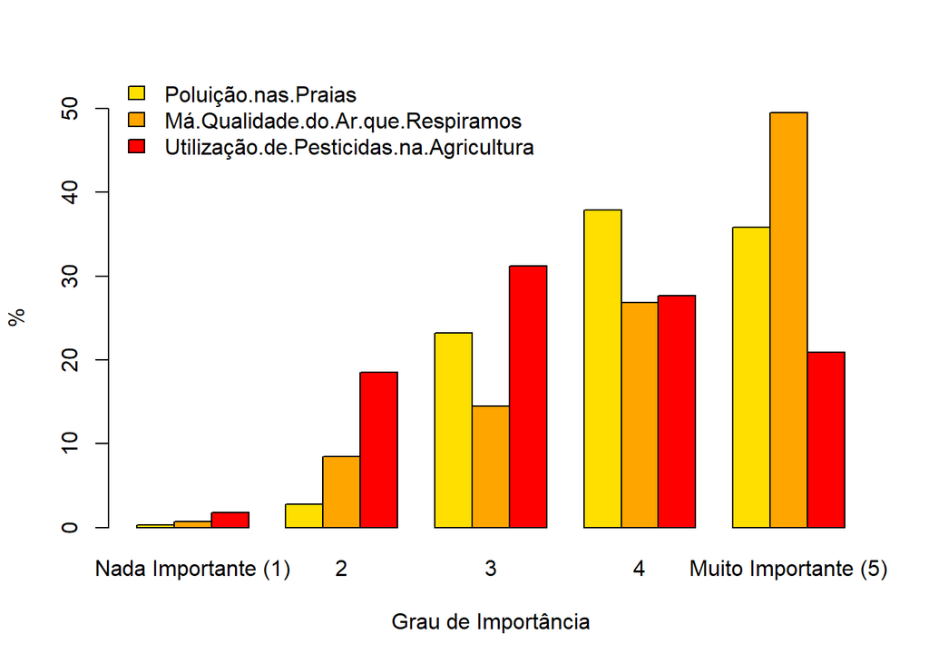

**Gráfico 2 -** Gráfico relativo ao grau de importância dos três problemas ecológicos em estudo, segundo os inquiridos.

.

Após o estudo do **Gráfico 2**, conclui-se que há um número relativamente reduzido de inquiridos que consideram estes três problemas “Nada importantes (1)”. Todavia, a “Má qualidade do ar que respiramos” é o problema ecológico considerado por mais inquiridos como “Muito importante” (49.5%).

No geral, a amostra considera estes problemas ecológicos relevantes, visto que a generalidade das respostas encontram-se entre o “3” e o “Muito importante (5)”.

O facto de a “Má qualidade do Ar que Respiramos” ser a problemática mais importante para a amostra em estudo já era de esperar, uma vez que este problema é, entre todos os problemas em estudo, aquele que afeta diretamente todos os inquiridos.

Pelo contrário, a “Poluição nas Praias” e “Utilização de Pesticidas na Agricultura” são problemáticas que, dependo da região em que o individuo se insere, podem ser mais ou menos relevantes consoante a influência que se faz sentir no mesmo.

Perante a possível variedade regional dos inquiridos é de enfatizar que das 3 problemáticas questionadas, aquela que obteve um maior número de não respostas (5% dos inquiridos) foi o problema inerentes à “Utilização de Pesticidas na Agricultura”, podendo ser indício de uma desinformação ou desinteresse da população para problemas deste tipo.

Tendo por base o referido anteriormente, podemos concluir que existe na atualidade uma elevada consciencialização para as problemáticas associadas à Ecologia.

.

## **3. Nível de Preocupação dos Inquiridos com a Destruição de Recursos Naturais**

.

No seguimento da análise do interesse da população perante a Ecologia, foi pedido aos inquiridos que numa escala de 0 a 100 avaliassem o seu nível de preocupação perante a destruição de Recursos Naturais.

No **Gráfico 3** e **Tabela 4** estão representadas as respostas a esta questão.

.

**Tabela de Medidas Descritivas do Nível de Preocupação com a Destruição de Recursos Naturais**

| Medidas Descritivas | Valor |
| --- | --- |
| n | 696.0 |
| Média | 85.4 |
| Mediana | 86.5 |
| Desvio Padrão | 12.9 |
| Variância | 165.6 |
| Mínimo | 20.0 |
| Máximo | 100.0 |
| 1º Quartil | 77.0 |
| 3º Quartil | 97.0 |

**Tabela 4 -** Medidas Descritivas do Nível de Preocupação com a Destruição de Recursos Naturais.

.

**Gráfico do Nível de Preocupação com a Destruição de Recursos Naturais em relação à Idade e às Habilitações Literárias**

.

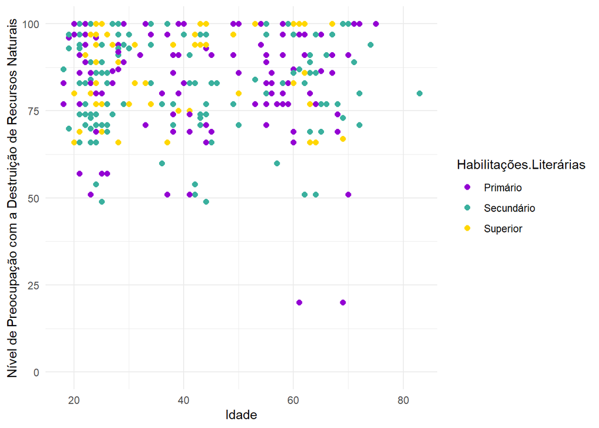

.

**Gráfico 3 -** Relação entre Nível de Preocupação com a Destruição de Recursos Naturais, a Idade e as Habilitações Literárias.

.

Relativamente ao “Nível de Preocupação com a Destruição de Recursos Naturais” as respostas dos inquiridos estão compreendidas entre 20 e 100, sendo que média é de 85.4 (DP = 12.9). Enfatiza-se ainda que sendo a escala até 100, 75% da amostra respondeu, no máximo, 97. (**Tabela 4**)

Segundo o **Gráfico 3**, a maior incidência de respostas encontra-se num nível de preocupação com a destruição de recursos naturais superior a 65, independentemente das habilitações literárias e da idade, o que revela uma generalização do conhecimento deste problema a todos os indivíduos.

Um dos factos a salientar da análise do **Gráfico 3** é que não se obtiveram respostas de preocupação abaixo de 65 por parte dos indivíduos com o ensino superior.

É de notar que a maior concentração de respostas reside entre os jovens (< 26 anos), aspeto este que é corroborado com o facto de os inquiridos serem maioritariamente desta faixa etária.

Em relação às habilitações literárias observa-se que há uma distribuição homogênea ao longo das idades, sendo que, por isso, ambas as variáveis não apresentam nenhuma relação linear com a preocupação dos inquiridos perante os recursos naturais.

Esta inexistência de relação é sustentada nas medidas de associação e correlação bivariadas pelo *R de Pearson* entre o “Nível de Preocupação com a Destruição de Recursos Naturais” e a “Idade” onde se obteve um coeficiente de **-0.045**, o que nos permite afirmar a ausência de relação.

O *Ró de Spearman* entre o “Nível de Preocupação com a Destruição de Recursos Naturais” e as “Habilitações Literárias”, obteve um coeficiente de **0.067** . Desta forma, podemos finalmente concluir que não se estabelece nenhuma relação linear entre estas variáveis.

Em suma, a preocupação dos inquiridos é independente do seu perfil, tal como já visível, havendo uma elevada sensibilização para os problemas associados à Ecologia

## **4. Influência da Educação na Perspetiva dos Inquiridos em Relação ao Ambiente**

.

A fim de perceber como é que a amostra em estudo constata a situação a Nível Nacional e Mundial dos problemas ecológicos, foi pedido aos inquiridos que classificassem a atual situação numa escala de 1 (“Muito Boa”) a 5 (“Muito Grave”).

.

**Gráficos das relações entre as Habilitações Literárias dos inquiridos com a Preocupação destes com Situação do Ambiente a Nível Nacional e Mundial**

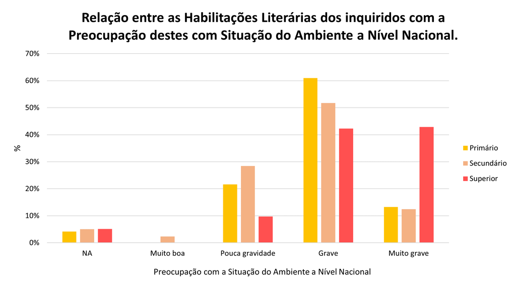

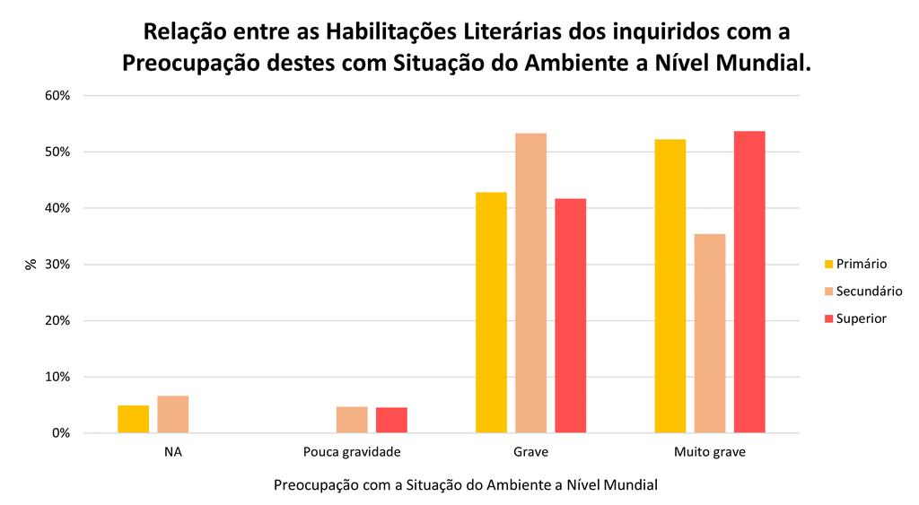

.

**Tabelas de Cruzamentos entre as Habilitações Literárias dos inquiridos com a Preocupação destes com a Situação do Ambiente a Nivel Nacional e Mundial**

.

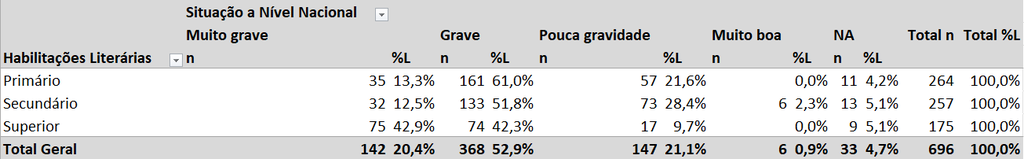

.

.

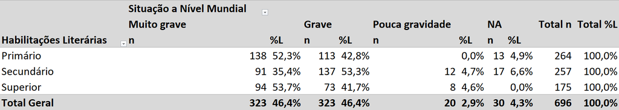

.

.

Segundo o **Gráfico 4**, do total dos inquiridos com o ensino Superior, 43% classificam a situação do ambiente a nível nacional como “Muito grave” e 42% como “Grave”.

Da amostra, 61% dos que concluíram o ensino primário e 52% dos que completaram o ensino Secundário, classificam o problema como “Grave”. No entanto, a situação apenas foi classificado como “Muito boa” por 2% das pessoas com o Secundário.

Salienta-se ainda o facto de não haver respostas, por pessoas com o ensino Primário, a mencionar que a situação se revela com “Pouca Gravidade”. Pode-se ainda observar que 53,3% das respostas por parte de alunos com o ensino Secundário consideraram como “Grave” à situação ambiental a nível mundial e que nenhum dos inquiridos a classificou como “Muito boa”, mesmo havendo essa opção no inquérito. (**Gráfico 5**)

Os inquiridos apresentam um nível de preocupação mais elevado referente à atual situação a nível mundial, onde a percentagem de respostas “Muito Grave” (46,4%) é superior, comparativamente, àquela que é vivenciada a nível nacional (20,4%). (**Tabela 5 e 6**)

Tal relação é mais expressiva nos indivíduos com o ensino Primário e Secundário, uma vez que cerca de 13% de cada um dos graus de escolaridade ter classificado como “Muito grave” a nível nacional, mas a nível mundial essa mesma classificação foi dada por 52% dos que realizaram o ensino Primário e 35% dos que realizaram o ensino Secundário. (**Tabelas 5 e 6**)

Face a estes dados, conclui-se que as pessoas, independentemente do tipo de habilitações literárias que possuem, são sensibilizadas para este tipo de problemas ecológicos que afetam direta ou indiretamente estes mesmos indivíduos.

.

## **Conclusão**

.

Os problemas ecológicos são iminentes na atualidade e foi na base destes que uma equipa de investigadores realizou uma recolha de dados que deu origem a este estudo.

Relativamente à amostra, verifica-se que há uma elevada heterogeneidade dos inquiridos, uma vez que, estes apresentam perfis demográficos distintos e variados, permitindo relacionar imparcialmente a relação entre estes e a Ecologia.

Conclui-se que os inquiridos classificam a situação ambiental a nível mundial com um grau de preocupação mais elevado do que a nível nacional, ou seja, classificam a situação em Portugal com menos problemas ambientais, relativamente com o mundo.

Em consonância com o referido no decorrer deste trabalho, é possível verificar ainda que não existe relação entre o nível de preocupação com a destruição de recursos naturais com a idade e com as habilitações literárias, sendo esta afirmação sustentada através do método “R de Pearson” e “Ró de Spearman”, respetivamente.

Relativamente ao dataset que nos foi facultado, acreditamos que um dos aspetos que beneficiaria a análise dos dados seria a presença de uma variável que indicasse a região dos inquiridos uma vez que se verificou poder existir uma relação com as distintas importâncias atribuídas aos problemas ambientais.

.

.

### **Bibliografia**

- Ecologia
- [R Markdown](http://rmarkdown.rstudio.com)
- [Ciência de Dados com R - Introdução](http://sillasgonzaga.com/material/cdr/)
- [R Markdown Cookbook](https://bookdown.org/yihui/rmarkdown-cookbook/)
- [Medidas de Associação e Correlação (Bivariadas) em R](http://www.sthda.com/english/wiki/correlation-test-between-two-variables-in-r)
- [Códigos de Cor](https://html-color.codes/gold)
- [ISCTE-IUL](https://www.iscte-iul.pt)
- Material fornecido pelos docentes